```r
v2= mydata %>%
  group_by(Segment) %>%
  summarize(total_sales2 = sum(total_sales)) %>%
  arrange(desc(total_sales2)) %>%
  head(6)
knitr::kable(v2,digits = 2,
             caption = "Table :Total sales per Segment",
             format = "html",
             table.attr = "style='width:40%:'",
             align = 'c')%>%
  kable_classic(bootstrap_options = "basic",
                full_width = TRUE,
                position = "center",
                font_size = 12)
```

Table :Total sales per Segment

| Segment | total_sales2 |
| --- | --- |
| Consumer | 41640653 |
| Corporate | 23377596 |
| Home Office | 12980145 |

```r
v3= mydata %>%
  group_by(Department) %>%
  summarize(total_sales3 = sum(total_sales)) %>%
  arrange(desc(total_sales3)) %>%
  head(5)
knitr::kable(v3,digits = 2,
             caption = "Table :Total sales per Department",
             format = "html",
             table.attr = "style='width:40%:'",
             align = 'c')%>%
  kable_classic(bootstrap_options = "basic",
                full_width = TRUE,
                position = "center",
                font_size = 12)
```

Table :Total sales per Department

| Department | total_sales3 |
| --- | --- |
| Office Supplies | 43461505 |
| Technology | 27764569 |
| Furniture | 6772320 |

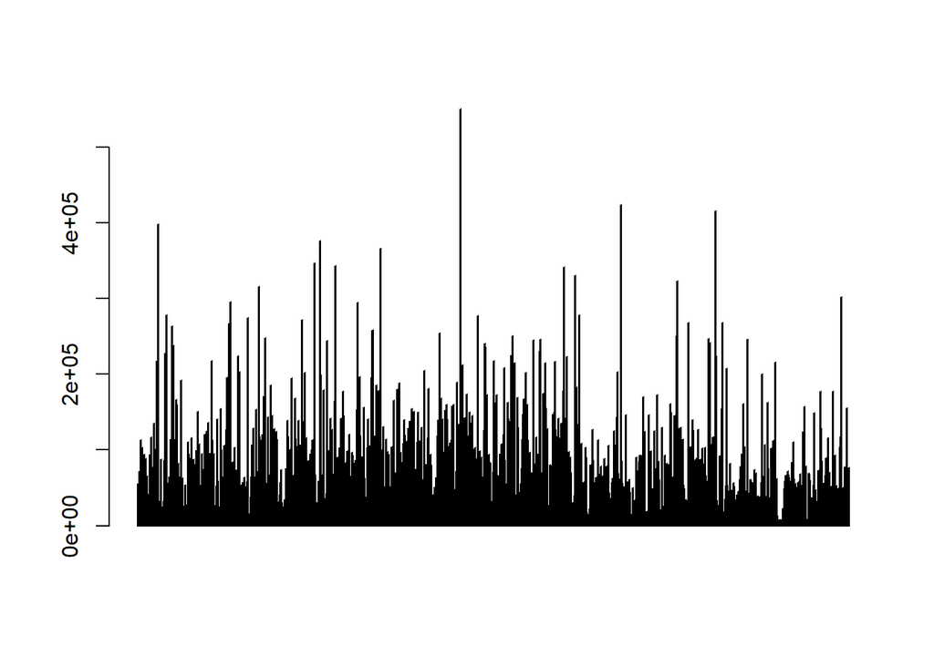

```r
barplot(mydata$total_sales, las= 0.5, col= heat.colors(8))
```

```r
##observations:In v1 table Asia Pacific has the highest total_sales that is 24704625,Africa has the lowest total sales of 5127296.in v2 table Home office has total sales of 12980145,consumer has a total sales of 41640653, and Corporate has total sales of  23377596.In v3 table Office Supplies has sales of 43461505,Technology has   sales of 27764569, Furniture has sales of   6772320
```

```r
#task8:
set = mydata%>%
  group_by(Department)%>%
  summarise(Total_dept = sum(total_sales))
knitr::kable(set,
             digits = 2,
             caption = "Table :Total sales per department",
             format = "html",
             table.attr = "style='width:40%:'",
             align = 'c')%>%
  kable_classic(bootstrap_options = "basic",
                full_width = TRUE,
                position = "center",
                font_size = 12)
```

Table :Total sales per department

| Department | Total_dept |
| --- | --- |
| Furniture | 6772320 |
| Office Supplies | 43461505 |
| Technology | 27764569 |

```r
t123 = dplyr::filter(mydata, Department == "Technology")

Dep_1 = table(t123$Division)
#Observations:From the table we deduce that the office supplies have been the highest in the department section with maximum number of sales reaching 43461505
```

CONCLUSIONS: By analyzing sales data across different departments, divisions, and segments,we can identify which products or services which are performing well, which ones are not, and which ones have the potential for growth.Shipping costs, quantity, and product price are all key metrics for sales data analysis. Shipping costs can impact the overall profitability of a sale, so it’s important to track them and look for ways to optimize them. Quantity sold can be an indicator of the popularity of a product, while product price can impact both sales volume and revenue.Overall, the direction of the sales data project will depend on the specific goals and objectives of the project. By analyzing sales data across different variables, gaining insights into the performance of products or services, identifying trends and patterns, and making data-driven decisions to improve sales performance and grow the business.New skills I gained while working on R projects Data manipulation and analysis: R is a powerful tool for data manipulation and analysis, allowing you to perform various statistical analyses, generate visualizations, and clean and transform data.

1.Programming and automation: R is a programming language, so working on an R project can improve your programming skills, especially in areas such as data structures, functions, and loops. Additionally, you can use R to automate repetitive tasks, saving you time and effort. 2.Collaboration and version control: When working on an R project, you can collaborate with other team members by using version control tools such as Git and GitHub. This allows you to track changes to your code, work on multiple versions of your project, and share your work with others. 3.Writing reports and documents: R can be used to generate reports and documents, such as HTML or PDF files, that contain your data analysis, code, and visualizations. This can help you communicate your findings to others in a clear and organized way. 4.Machine learning and predictive modeling: R has a wide range of libraries and packages for machine learning and predictive modeling, which can help you build models to make predictions and classify data based on patterns and trends. I Contributed by fixing bugs, adding new features, or creating entirely new packages that address specific needs or problems.I suggest joining R user groups and forums which are a great place to connect with other R users and share your knowledge and experiences.I Provided feedback and suggestions:reporting bugs, suggesting new features, or providing feedback on existing features.

References:1.Africapolis. (2021). African Urbanization Dynamics 2021: Data, Maps and Statistics. Retrieved from https://www.africapolis.org/african-urbanization-dynamics-2021-data-maps-and-statistics/

2.Arvis, J.-F., Duval, Y., Shepherd, B., Utoktham, C., & Wiederer, C. (2013). Trade costs in the developing world: 1995-2010. World Bank Policy Research Working Paper No. 6309. Retrieved from https://papers.ssrn.com/sol3/papers.cfm?abstract_id=2202674

3.Kouni, M., Tsioumas, V., & Papageorgiou, L. G. (2019). Analysing trade and transport networks: Evidence from the European Union. Journal of Transport Geography, 74, 1-10. https://doi.org/10.1016/j.jtrangeo.2018.12.003

4.Jankowska, A., & Guzik, J. (2021). Logistics performance of countries in Africa, Asia, and Latin America: An empirical study based on data from the World Bank. Transportation Research Part E: Logistics and Transportation Review, 156, 102155. https://doi.org/10.1016/j.tre.2021.102155

5.Vaze, V., & D’Souza, R. (2020). A review of seaport performance measurement models with an emphasis on Asia-Pacific region. Maritime Policy & Management, 47(5), 563-584. https://doi.org/10.1080/03088839.2020.1750475